# intermediate generalized linear models

Ben Bolker

## packages

```r
library(ggplot2); theme_set(theme_bw())
library(aods3)
```

# overdispersion

## overdispersion

- more variance than expected based on statistical model
- e.g. variance > mean for Poisson
- in general leads to *overconfidence*
  - overly narrow confidence intervals
  - too-small p-values
  - inflated type I error

## Tick example

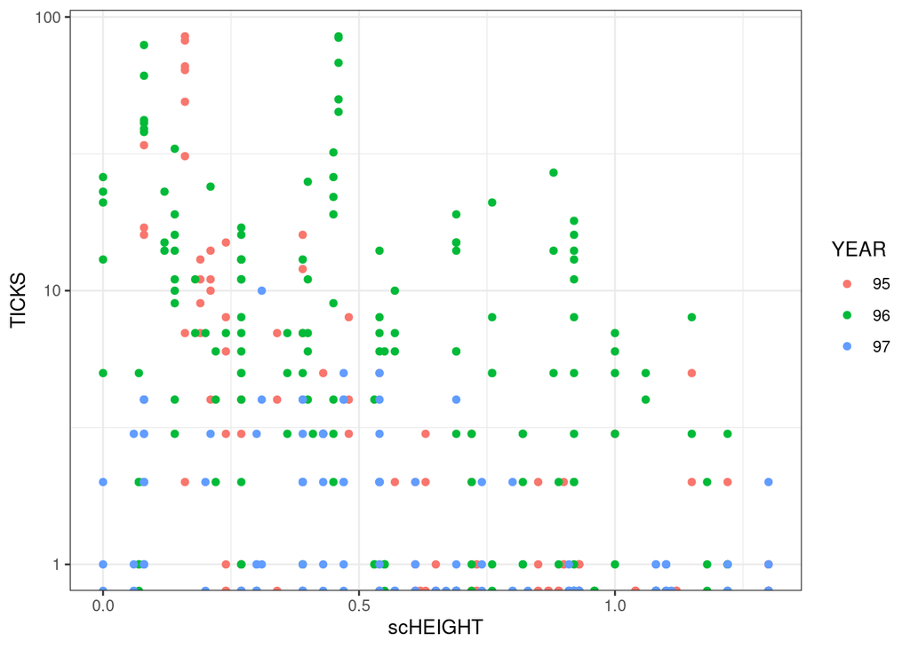

```r
ticks <- read.table("../../data/Elston2001_tickdata.txt",header=TRUE)
ticks <- transform(ticks,
          YEAR=factor(YEAR),
          scHEIGHT=(HEIGHT-min(HEIGHT))/100)
ggplot(ticks,aes(scHEIGHT,TICKS,colour=YEAR))+
    geom_point()+
    scale_y_log10()
```

```r
ticks_glm1 <- glm(TICKS~scHEIGHT*YEAR,ticks,family=poisson)
aods3::gof(ticks_glm1)
```

```
## D  = 3008.964, df = 397, P(>D) = 0
## X2 = 4496.887, df = 397, P(>X2) = 0
```

## methods

- quasi-likelihood models
- compounded distributions
- observation-level random effects

## quasi-likelihood

- quantify excess variance
- e.g. $\phi$=`sum(residuals(m,type="pearson")^2)/df.residual(m)`
- multiply estimated standard errors by $\sqrt{phi}$
- recompute $Z$/$t$ statistics, $p$ values
- `family=quasipoisson` or `family=quasibinomial` does this automatically
- quasilikelihood/quasiAIC? Depends who you ask.

## ticks

```r
ticks_QP <- update(ticks_glm1,family=quasipoisson)
summary(ticks_QP)
```

```
##
## Call:
## glm(formula = TICKS ~ scHEIGHT * YEAR, family = quasipoisson,
##     data = ticks)
##
## Coefficients:
##                 Estimate Std. Error t value Pr(>|t|)
## (Intercept)       4.0008     0.2391  16.731  < 2e-16 ***
## scHEIGHT         -5.8198     0.8547  -6.809 3.64e-11 ***
## YEAR96           -0.9831     0.2729  -3.603 0.000355 ***
## YEAR97           -2.9448     0.5057  -5.824 1.19e-08 ***
## scHEIGHT:YEAR96   4.4693     0.8959   4.988 9.12e-07 ***
## scHEIGHT:YEAR97   4.0453     1.2081   3.349 0.000890 ***
## ---
## Signif. codes:  0 '***' 0.001 '**' 0.01 '*' 0.05 '.' 0.1 ' ' 1
##
## (Dispersion parameter for quasipoisson family taken to be 11.3272)
##
##     Null deviance: 5847.5  on 402  degrees of freedom
## Residual deviance: 3009.0  on 397  degrees of freedom
## AIC: NA
##
## Number of Fisher Scoring iterations: 6
```

## compounded distributions

```r
ticks_NB <- MASS::glm.nb(TICKS~scHEIGHT*YEAR,data=ticks)

summary(ticks_NB)
```

```
##
## Call:
## MASS::glm.nb(formula = TICKS ~ scHEIGHT * YEAR, data = ticks,
##     init.theta = 0.9000852793, link = log)
##
## Coefficients:
##                 Estimate Std. Error z value Pr(>|z|)
## (Intercept)       3.3829     0.2323  14.559  < 2e-16 ***
## scHEIGHT         -4.1308     0.4033 -10.242  < 2e-16 ***
## YEAR96           -0.2890     0.2829  -1.022 0.307009
## YEAR97           -2.1926     0.3286  -6.672 2.52e-11 ***
## scHEIGHT:YEAR96   2.6132     0.4824   5.418 6.04e-08 ***
## scHEIGHT:YEAR97   2.0861     0.5571   3.745 0.000181 ***
## ---
## Signif. codes:  0 '***' 0.001 '**' 0.01 '*' 0.05 '.' 0.1 ' ' 1
##
## (Dispersion parameter for Negative Binomial(0.9001) family taken to be 1)
##
##     Null deviance: 840.71  on 402  degrees of freedom
## Residual deviance: 418.82  on 397  degrees of freedom
## AIC: 1912.6
##
## Number of Fisher Scoring iterations: 1
##
##
##               Theta:  0.9001
##           Std. Err.:  0.0867
##
##  2 x log-likelihood:  -1898.5880
```

```r
## or:
library(glmmTMB)
glmmTMB(TICKS~scHEIGHT*YEAR,data=ticks,family=nbinom2)
```

```
## Formula:          TICKS ~ scHEIGHT * YEAR
## Data: ticks
##       AIC       BIC    logLik  df.resid
## 1912.5876 1940.5801 -949.2938       396
##
## Number of obs: 403
##
## Dispersion parameter for nbinom2 family ():  0.9
##
## Fixed Effects:
##
## Conditional model:
##     (Intercept)         scHEIGHT           YEAR96           YEAR97
##           3.383           -4.131           -0.289           -2.193
## scHEIGHT:YEAR96  scHEIGHT:YEAR97
##           2.613            2.086
```

## observation-level random effects

- use mixed models; add a Normal deviate to each observation  
  (on the link-function/linear predictor scale)
- e.g. logit-Normal-binomial, or log-Normal-Poisson

```r
library(lme4)
ticks <- transform(ticks,
        obs=1:nrow(ticks))
ticks_OR <- glmer(TICKS~scHEIGHT*YEAR+(1|obs),data=ticks,
                  family=poisson)
summary(ticks_OR)
```

```
## Generalized linear mixed model fit by maximum likelihood (Laplace
##   Approximation) [glmerMod]
##  Family: poisson  ( log )
## Formula: TICKS ~ scHEIGHT * YEAR + (1 | obs)
##    Data: ticks
##
##      AIC      BIC   logLik deviance df.resid
##   1903.0   1931.0   -944.5   1889.0      396
##
## Scaled residuals:
##      Min       1Q   Median       3Q      Max
## -1.29773 -0.50197 -0.06591  0.22414  1.91379
##
## Random effects:
##  Groups Name        Variance Std.Dev.
##  obs    (Intercept) 1.132    1.064
## Number of obs: 403, groups:  obs, 403
##
## Fixed effects:
##                 Estimate Std. Error z value Pr(>|z|)
## (Intercept)       2.7402     0.2429  11.283  < 2e-16 ***
## scHEIGHT         -4.0492     0.4155  -9.746  < 2e-16 ***
## YEAR96           -0.2069     0.2958  -0.699  0.48435
## YEAR97           -1.9407     0.3482  -5.573 2.51e-08 ***
## scHEIGHT:YEAR96   2.5381     0.5026   5.050 4.42e-07 ***
## scHEIGHT:YEAR97   1.8683     0.5889   3.173  0.00151 **
## ---
## Signif. codes:  0 '***' 0.001 '**' 0.01 '*' 0.05 '.' 0.1 ' ' 1
##
## Correlation of Fixed Effects:
##                (Intr) scHEIGHT YEAR96 YEAR97 sHEIGHT:YEAR96
## scHEIGHT       -0.830
## YEAR96         -0.818  0.682
## YEAR97         -0.693  0.580    0.568
## sHEIGHT:YEAR96  0.689 -0.826   -0.835 -0.480
## sHEIGHT:YEAR97  0.592 -0.704   -0.485 -0.834  0.583
```

## offsets

- account for differences in sampling effort, exposure
- count data: typically `log(effort)`, `log(area)` etc.
- `y ~ x + offset(log(e))`: $\exp(\log(y)) = \exp(\beta_0 + \beta_1 x + \log(e))$ or
  $$y = \exp(\beta_0 + \beta_1 x) \cdot \exp(\log(e)) = e \cdot \exp(\beta_0 + \beta_1 x)$$
- predictions are for 1 unit of effort/area
- for mortality risk: $\log(t)$ on *complementary log-log link* scale (see [here](https://rpubs.com/bbolker/logregexp))

## complete separation

- what happens when a logistic regression model is too good?
- some threshold: all below=0, all above=1
- best slope estimate on logit scale is *infinite*
- Wald approximation breaks down (*Hauck-Donner effect*)
- symptoms: $|\beta|>10$, crazy SEs and terrible p-values
- strong effects, or slicing data too thin

## solutions

- model comparison (`anova()`) still works
- profile CI should get *lower* limit of parameters
- penalization (`brglm`, “Firth’s method”)
- Bayesian approaches: put a prior on parameters (`blme`, `brms`)

# zero-inflation

## zero-inflation [@martin_zero_2005]

- *too many* zeros
- “lots of zeros” can occur just because of low mean
- mode at zero *and* away from zero usually does mean Z-I

## zero-inflation models

- *zero-inflation*: mixture of structural and sampling zeroes  
  (**not** “true” and “false”)
- *hurdle*: zeros plus truncated distribution
- choice depends on meaning of zeros
- Z-I as well as conditional mean may be modeled (e.g. `glmmTMB`)

## testing for zero-inflation

- a little tricky
- easiest (?) to fit Z-I model and then test whether you needed it or not
- *posterior predictive simulation*

## posterior simulation

Use the `simulate()` method, if available

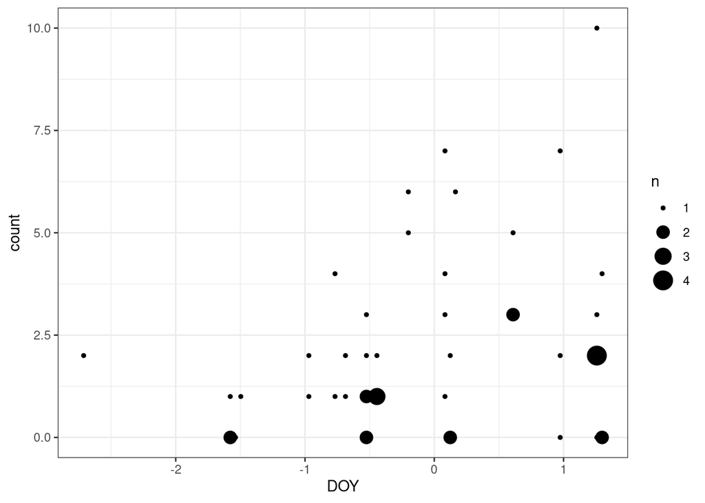

```r
data(Salamanders,package="glmmTMB")
ss <- subset(Salamanders,spp=="GP" & mined=="no")
## fit model
ggplot(ss,aes(DOY,count))+stat_sum()
```

```r
salam_1 <- glm(count~DOY,ss,family=poisson)
## simulate 1000 realizations from the model
sims <- simulate(salam_1,1000)
## count proportions of zeros per simulation
zero_prop <- prop.table(table(colSums(sims==0)))
zero_ind <- as.numeric(names(zero_prop))
obs_zeros <- sum(ss$count==0)
## p-value
sum(zero_prop[zero_ind>=obs_zeros])
```

```
## [1] 0.054
```

## zero-inflation plot

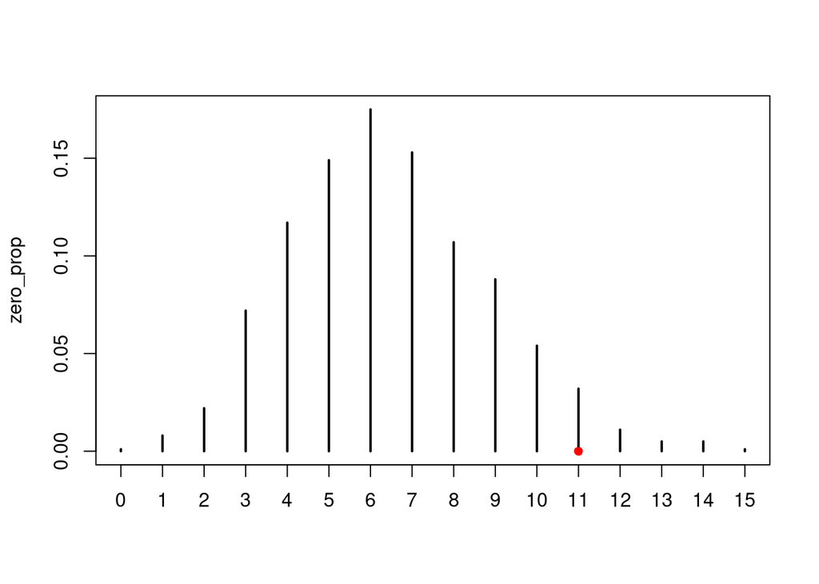

```r
plot(zero_prop)
points(obs_zeros,0,col="red",pch=16)
```

## alternative families and links

## Gamma

- useful
- simply log-transforming may be easier: log-Normal very similar to Gamma in some ways
- choose based on interpretation; behaviour near zero; tail behaviour

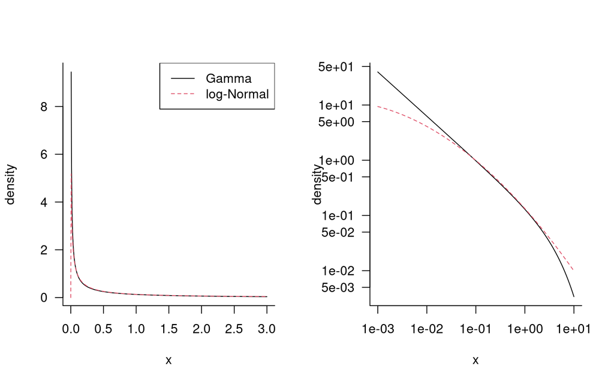

## complementary log-log link

- useful for discrete-time survival analysis
- parameters on the *log-hazard* scale

# beyond the exponential family

## beta regression

- GLMs require counts (denominators), e.g. 40% = 4/10
- what if data don’t have obvious denominators?
- e.g. cover scores, activity budgets
- *Beta distribution*: `betareg`, `glmmTMB`, `brms`

## negative binomial regression

- for overdispersion
- standard NB (“NB2”): Gamma+Poisson, variance = $\mu(1+\mu/k)$, $k >0$
- NB1: variance=$\mu \phi$, $\phi>1$

## others …

- beta-binomial (overdispersed binomial)
- Tweedie (zeros + continuous)
- COM-Poisson, generalized Poisson [@lynch_dealing_2014]
- ordinal models (`MASS::polr`, `ordinal` package)